# Suicide Notebook

David Herel

14.12.2020

## Introduction

In this notebook I want to make a closer look on Suicide dataset, analyze it and make some predictive models.

## Part I - Exploratory analysis of the suicide dataset

In this part I will load the dataset and visualize the main relationships and trends,

### Analyze variables

So what about to start with analyzing dataset? At **first**, we look on interesting variables and their behavior.

Let’s start with most interesting one:

#### Generation

#

[figure not shown]

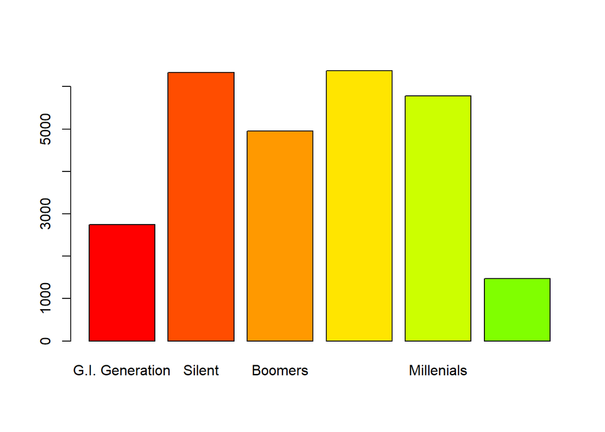

```r
#load data in to "data"
load(file="suicide.RData")

barplot(table(data$generation),col = rainbow(20))
```

We can see that generation **G.I.** and **Z** are not so big as others. My explanation is that we can view all generations as **Gauss distribution**, where **G.I.** is at the start of distribution and **generation Z** is at the end of distribution. Both generation dont have so many people in their group, because either they are too old or too young

#### Sex

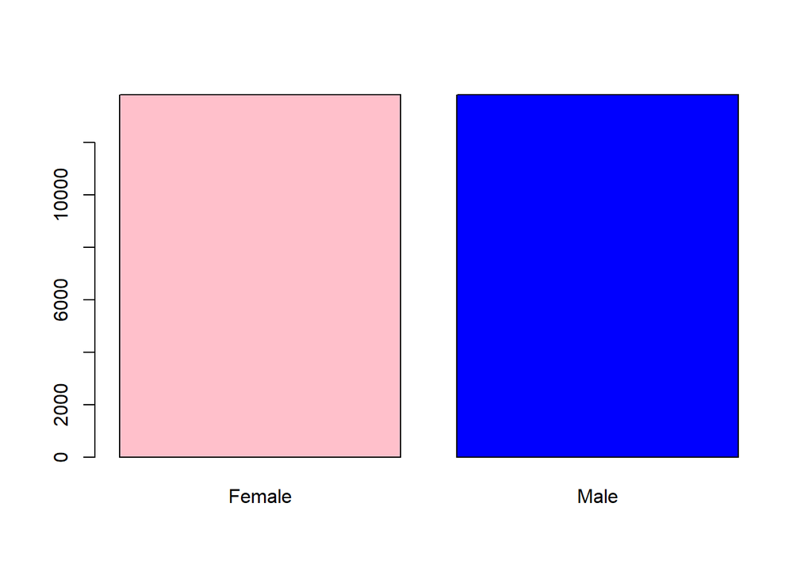

```r
barplot(table(data$sex), col=c("pink", "blue"))
```

We can see we **same number** of males in females in dataset.

#### Age

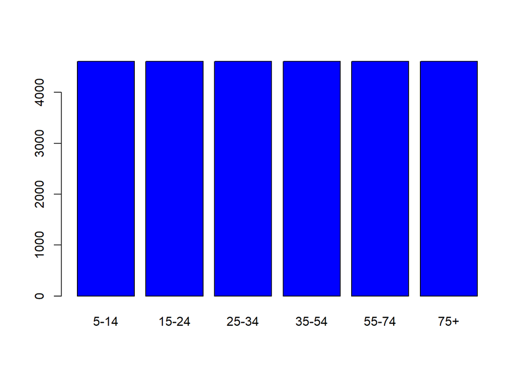

```r
barplot(table(data$age), col="blue")
```

This is really **weird** for me. I would not divide data in these categories. I would make one category **for each age**. But I guess they chosed these categories because that makes data **equally distributed**.

#### Continent

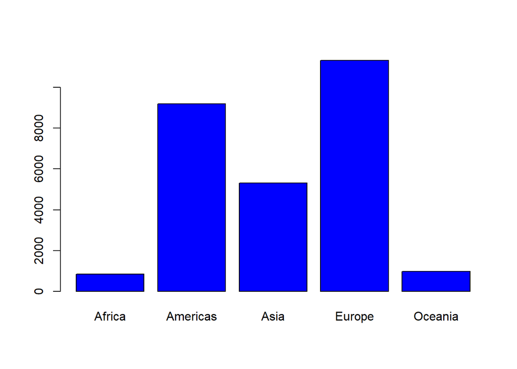

```r
barplot(table(data$continent), col="blue")
```

I wanted to have a look on **countries** at first. But there were too many of them and it was **difficult** to read.

So when we switch to continents. We can see most data comes from **Europe and America**.

So it is possible that the models and prediction will be more accurate for **them** and not so good for **other continents** like Africa or Oceania.

### Analyze correlations

Now we analyzed key variables and it is time to move on some **‘high-level’** charts like interesting correlations.

#### Suicide ratio

What about overall **suicide rate**? Is it increasing, decreasing or stagnating?

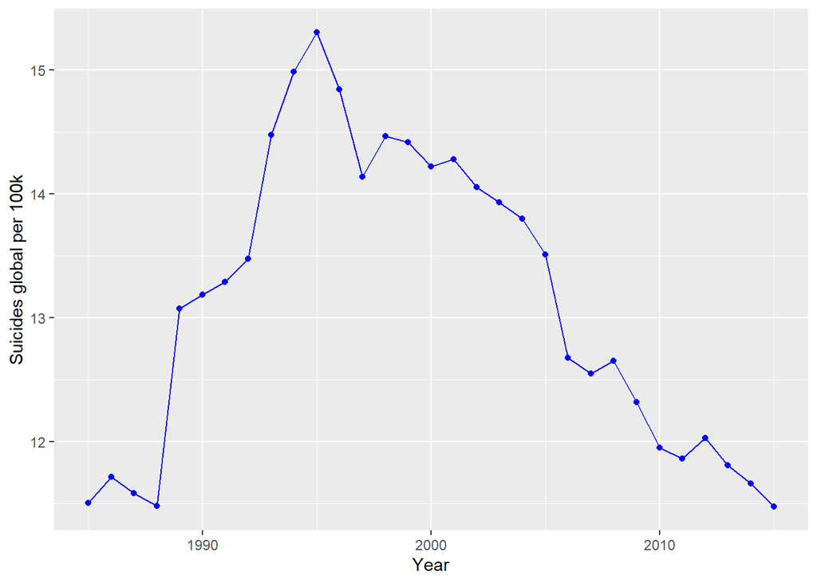

```r
#libraries
library(magrittr)
library(dplyr)
library(ggplot2)


data_plot_suicide = data %>% # using suicide_data
  group_by(year) %>% # group all the data from the same year
  summarize(
            suicides_100k = (sum(suicides_no) / sum(population)) * 100000)

ggplot(data = data_plot_suicide,
                      aes(x = year, y = suicides_100k)) +
  # points to each peak
  geom_point(col = 'blue') +

  # line of points
  geom_line(col = 'blue') +

  #change labels
  ylab('Suicides global per 100k') +
  xlab('Year')
```

If we see this **model**. Everyone would predict that in couple of years the suicide rate will be even lower. But **COVID-19** hit. And we can see that suicides are massively increasing [^1] [^2].

To have a **correct** prediction we would have to develop model which can predict, when war **strikes or pandemic strikes** etc. And that is impossible in **near future**, in my opinion.

#### Man vs female

This statistics should be pretty **accurate** because there is equal number man and woman in dataset.

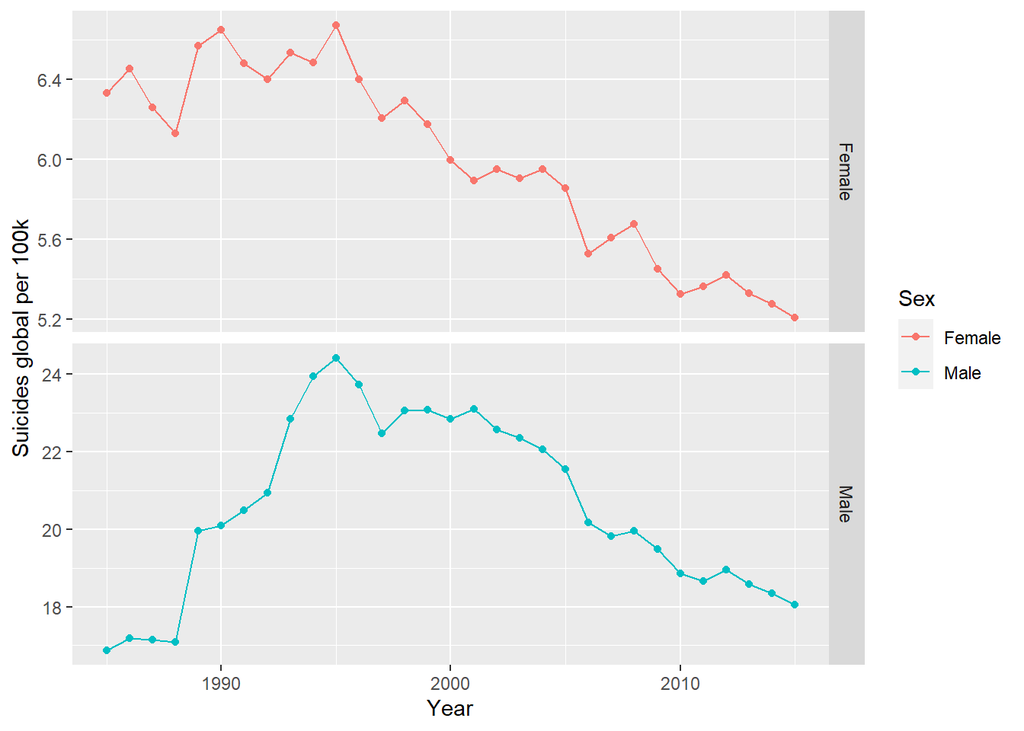

```r
library("pdp")

#same as in previous for global age
suicide_data_sex = data %>%
  group_by(year, sex) %>%
  summarize(suicide_100k = (sum(suicides_no) / sum(population)) * 100000)


ggplot(data = suicide_data_sex,
       aes(x = year, y = suicide_100k, col = factor(sex))) +
  facet_grid(sex ~ ., scales = "free_y") +

  geom_line() +
  geom_point() +

  #change labels
  xlab('Year') +
  ylab('Suicides global per 100k')+

  #change legend -> from factor(sex) to sex
  labs(color = 'Sex')
```

We see that **males** have a lot more suicides than **females**. There is not a single year, when females ‘wins’. We could maybe use classical barplot for overall result, but I was more interested in **timeline** and how or if it changed.

#### Continents

There we will not get accurate results because, as I showed few sections before, we have far far more data from Europe/America than from other continents. So there can be huge **innaccuracy**.

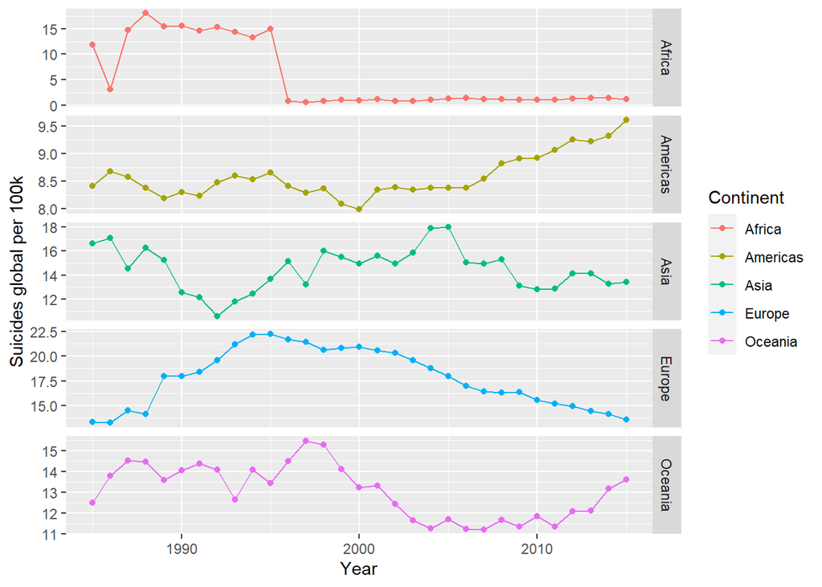

```r
#same as in previous for global age
suicide_data_continent = data %>%
  group_by(year, continent) %>%
  summarize(suicide_100k = (sum(suicides_no) / sum(population)) * 100000)


ggplot(data = suicide_data_continent,
       aes(x = year, y = suicide_100k, col = factor(continent))) +
  facet_grid(continent ~ ., scales = "free_y") +

  geom_line() +
  geom_point() +

  #change labels
  xlab('Year') +
  ylab('Suicides global per 100k')+

  #change legend -> from factor(sex) to sex
  labs(color = 'Continent')
```

**Europe** has the most of suicides per 100k, but we see that this trend is **decreasing** over time. However in **America** it does do opposite - **increases**. **Asia oscilates** and is in middle - between America and Europe.

Oceania and Africa is not worth commenting, because we dont have enough data, in my opinion.

#### Age

In plot, few sections before, we saw that this variable is **equal among all categories** so the results will be accurate too.

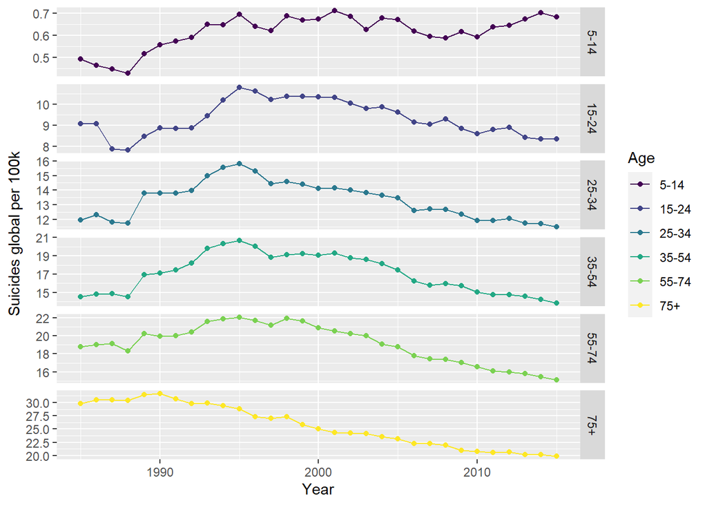

```r
#same as in previous for global age
suicide_data_age = data %>%
  group_by(year, age) %>%
  summarize(suicide_100k = (sum(suicides_no) / sum(population)) * 100000)

ggplot(data = suicide_data_age,
       aes(x = year, y = suicide_100k, col = factor(age))) +
  facet_grid(age ~ ., scales = "free_y") +

  geom_line() +
  geom_point() +

  #change labels
  xlab('Year') +
  ylab('Suicides global per 100k')+

  #change legend -> from factor(age) to age
  labs(color = 'Age')
```

We can see that almost in all age categories the trend is decreasing over time. Also it is obvious, that most of suicides are committed by older people.

We can really say: **The older you are, the higher chance of commiting suicide you have.**

## Part 2

From part 1, we have really interesting hypotheses. In this part we will test some of those.

### Age differences

In graph before we see that age affect suicide ratio. So we will test this hypothesis.

Does the categorical independent variable **age** affect the dependent variable **suicide rates**? In other words we test if the mean in all age groups is the same or not.

H0: The **mean** value of the groups is the same

H1: The **mean** value of the groups is not the same

#### ANOVA

We can use ANOVA method to test it. More explicitly one-way ANOVA.

```r
anova_age = aov(suicide_data_age$suicide_100k~suicide_data_age$age)
summary(anova_age)
```

```
##                       Df Sum Sq Mean Sq F value Pr(>F)
## suicide_data_age$age   5  11534  2306.7   494.6 <2e-16 ***
## Residuals            180    840     4.7
## ---
## Signif. codes:  0 '***' 0.001 '**' 0.01 '*' 0.05 '.' 0.1 ' ' 1
```

```r
summary(anova_age)[[1]][["Pr(>F)"]][1]
```

```
## [1] 4.076372e-103
```

We see really low p-value(far below 0.05). So we reject H0 hypothesis. So **we see that age really affects suicide rates**.

But we have to check our assumptions, because if they are not fulfilled we can’t use this result.

#### Shapiro-wilk test

First assumption:

**Does residuals in each group follow a normal distribution?**

We will check this by using Shapiro-Wilk test.

```r
age_residuals = residuals(object = anova_age)
shapiro.test(age_residuals)
```

```
##
##  Shapiro-Wilk normality test
##
## data:  age_residuals
## W = 0.97779, p-value = 0.004638
```

Unfortunately, p-value is bellow 0.05 so we have to reject that residuals have normal distribution.

#### Levene’s test

**Is variance same in all groups?**

We will check this by using Levene’s test.

```r
library(car)
leveneTest(suicide_data_age$suicide_100k~suicide_data_age$age)
```

|  | Df | F value | Pr(>F) |
| --- | --- | --- | --- |
| group | 5 | 43.64308 | 2.481156e-29 |
|  | 180 | NA | NA |

Again, p-value is under 0.05 so we have to reject H0. That means that variance is **NOT** same in all groups.

Not a single assumption is fulfilled so ANOVA did not gave us correct results.

But, if ANOVA assumption fails. We can use non-parametric tests. For example: **Kruskal-Wallis test**.

#### Kruskal-wallis test

```r
library(car)
kruskal.test(suicide_data_age$suicide_100k~suicide_data_age$age)
```

```
##
##  Kruskal-Wallis rank sum test
##
## data:  suicide_data_age$suicide_100k by suicide_data_age$age
## Kruskal-Wallis chi-squared = 172.34, df = 5, p-value < 2.2e-16
```

The p-value is below 0.05 so H0 is rejected.

Now we can safely say that: **Mean value of the groups is not the same - so age affect suicide rate**.

### Sex differences

Does the categorical independent variable **sex** affect the dependent variable **suicide rates**? In other words we test if the mean in two sex groups is the same or not.

H0: The **mean** value of the groups is the same

H1: The **mean** value of the groups is not the same

As in first hypothesis, we can use ANOVA method to test it. More explicitly **one-way ANOVA**.

#### ANOVA

```r
anova_sex = aov(suicide_data_sex$suicide_100k~suicide_data_sex$sex)
summary(anova_sex)
```

```
##                      Df Sum Sq Mean Sq F value Pr(>F)
## suicide_data_sex$sex  1   3308    3308    1220 <2e-16 ***
## Residuals            60    163       3
## ---
## Signif. codes:  0 '***' 0.001 '**' 0.01 '*' 0.05 '.' 0.1 ' ' 1
```

```r
summary(anova_sex)[[1]][["Pr(>F)"]][1]
```

```
## [1] 1.412057e-41
```

P-value is again under 0.05. We can safely reject H0 hypothesis.

So **we see that sex really affects suicide rates**.

What about assumptions? We check them as in hypothesis above.

First assumption:

**Does residuals in each group follow a normal distribution?**

We will check this by using Shapiro-Wilk test.

#### Shapiro-wilk test

```r
sex_residuals = residuals(object = anova_sex)
shapiro.test(sex_residuals)
```

```
##
##  Shapiro-Wilk normality test
##
## data:  sex_residuals
## W = 0.96215, p-value = 0.05319
```

Finally, the p-value is higher than 0.05 :)

We will not reject H0 - so **residuals have normal distribution**.

**Is variance same in all groups?**

We will check this by using Levene’s test.

#### Levene’s test

```r
library(car)
leveneTest(suicide_data_sex$suicide_100k~suicide_data_sex$sex)
```

|  | Df | F value | Pr(>F) |
| --- | --- | --- | --- |
| group | 1 | 49.24028 | 2.338705e-09 |
|  | 60 | NA | NA |

Unfortunately, p-value is under 0.05 so we have to reject H0. That means that variance is **NOT** same in all groups.

Even thought, only this assumption is violated. We still can not rely on ANOVA results.

We are again forced to use **Kruskal-Wallis test**.

#### Kruskal-wallis test

```r
library(car)
kruskal.test(suicide_data_sex$suicide_100k~suicide_data_sex$sex)
```

```
##
##  Kruskal-Wallis rank sum test
##
## data:  suicide_data_sex$suicide_100k by suicide_data_sex$sex
## Kruskal-Wallis chi-squared = 45.762, df = 1, p-value = 1.335e-11
```

The p-value is below 0.05 so we can safely reject H0.

Now we are confirmed that: **Mean value of the groups is not the same - so sex affect suicide rate**.

### Continent differences

Does the categorical independent variable **continent** affect the dependent variable **suicide rates**? In other words we test if the mean in continent groups is the same or not.

H0: The **mean** value of the groups is the same

H1: The **mean** value of the groups is not the same

As in above hypothesis, we can use **one-way ANOVA method** to test it.

#### ANOVA

```r
anova_continent = aov(suicide_data_continent$suicide_100k~suicide_data_continent$continent)
summary(anova_continent)
```

```
##                                   Df Sum Sq Mean Sq F value Pr(>F)
## suicide_data_continent$continent   4   2898   724.6    63.7 <2e-16 ***
## Residuals                        150   1706    11.4
## ---
## Signif. codes:  0 '***' 0.001 '**' 0.01 '*' 0.05 '.' 0.1 ' ' 1
```

```r
summary(anova_continent)[[1]][["Pr(>F)"]][1]
```

```
## [1] 2.225073e-31
```

P-value is again under 0.05. We can safely reject H0 hypothesis.

So **we see that continent really affects suicide rates**.

What about assumptions? We check them as in hypothesis above.

First assumption:

**Does residuals in each group follow a normal distribution?**

We will check this by using Shapiro-Wilk test.

#### Shapiro-wilk test

```r
continent_residuals = residuals(object = anova_continent)
shapiro.test(continent_residuals)
```

```
##
##  Shapiro-Wilk normality test
##
## data:  continent_residuals
## W = 0.89268, p-value = 3.37e-09
```

Sadly p-value is a lot lower than 0.05 :(

We will reject H0 - so **residuals dont have normal distribution**.

**Is variance same in all groups?**

We will check this by using Levene’s test.

#### Levene’s test

```r
library(car)
leveneTest(suicide_data_continent$suicide_100k~suicide_data_continent$continent)
```

|  | Df | F value | Pr(>F) |
| --- | --- | --- | --- |
| group | 4 | 9.567587 | 6.440698e-07 |
|  | 150 | NA | NA |

Unfortunately, p-value is under 0.05 so we have to reject H0. That means that variance is **NOT** same in all groups.

All assumptions are again violated. We can not rely on ANOVA results.

We are again forced to use **Kruskal-Wallis test**.

#### Kruskal-wallis test

```r
library(car)
kruskal.test(suicide_data_continent$suicide_100k~suicide_data_continent$continent)
```

```
##
##  Kruskal-Wallis rank sum test
##
## data:  suicide_data_continent$suicide_100k by suicide_data_continent$continent
## Kruskal-Wallis chi-squared = 94.608, df = 4, p-value < 2.2e-16
```

The p-value is below 0.05 so we can safely reject H0.

Now we are confirmed that: **Mean value of the groups is not the same - so continent affect suicide rate**.

## Part 3

We will use learnAndTest function from hw01. Where the X input is matrix of independent variables and Y input is matrix of dependent variable. This function also employs cross-validation.

```r
library(caret)
learnAndTest <- function(X, Y, modelType, ...) {
  data <- data.frame(X, Y)

  train.control <- trainControl(method = "cv", number = 10) # 10-fold cross-validataion
  # Alternative to get more accurate, but slower evaluation:
  # train.control <- trainControl(method = "LOOCV")

  # Here we train the model using the versatile `train` function from the caret package
  train(Y ~.,
                 data = data,
                 method = modelType,
                 trControl = train.control,
                 ...)

}
```

### Linear regression

```r
library(dplyr)
dependend_matrix <- data$suicides_no
independend_matrix <- select(data, country, year, sex, age, population, gdp_for_year, gdp_per_capita, generation, continent)

print(learnAndTest(independend_matrix, dependend_matrix, "lm"))
```

```
## Linear Regression
##
## 27660 samples
##     9 predictor
##
## No pre-processing
## Resampling: Cross-Validated (10 fold)
## Summary of sample sizes: 24894, 24893, 24894, 24893, 24894, 24894, ...
## Resampling results:
##
##   RMSE      Rsquared   MAE
##   600.0601  0.5607675  242.3251
##
## Tuning parameter 'intercept' was held constant at a value of TRUE
```

We can see that our model can explain more than **55%** of suicides. However **RMSE** is around 600 so we did not fit the data perfectly (0 would be the desired value).

```r
library(dplyr)
library(caret)

dependend_matrix <- data$suicides_no
independend_matrix <- select(data, country, year, sex, age, population, gdp_for_year, gdp_per_capita, generation, continent)

#Polynomial regression
#print(learnAndTest(independend_matrix, dependend_matrix, "krlsPoly"))

#Neural network model
#print(learnAndTest(independend_matrix, dependend_matrix, "brnn"))

# Polynomial model
#print(learnAndTest(independend_matrix, dependend_matrix, "krlsPoly"))
```

## Discussion

Assignment was **great**! For me it was the most interesting topic and I enjoyed analyzing this dataset. But what I am curious about is to predict **future suicides**.

Which due to **coronavirus**, we can see that it is nearly impossible to predict its occurrence from past data. Because the world is too complex and we can not even successfully predict population rate, because pandemic, war, meteoric or **anything** could happen. We can just say that with xy% we are sure that population will increase etc..

I was thinking about it for a while. How we could achieve this model which predict future? If the universe is deterministic, if we knew positions of all atoms in the universe and apply function on them we could see what will happen next. But it is impossible to know position of all atoms now. Ok, I get too deep in my thoughts haha, but I think we are making great progress in prediction, just look at huge succes with AlphaFold :)

Now we can compare our results with **WHO** results. We can see that we have same results in suicide ratio, which is decreasing in their’s dataset too. Also male/female and age statistics is **same too.**

Unfortunately their summary is more about prevention and for example says that for every **successful** suicide there is **20 unsuccessful**. And also that for people, that are **15-29 years old** it is the second leading cause of death. These trends we can not observe in our dataset :(

However we still got interesting results from our work. Future work could be to test more complicated hypothesis.

Thanks for the attention :)

#

[figure not shown]

[^1]: Gunnell D, Appleby L, Arensman E, et al., COVID-19 Suicide Prevention Research Collaboration. Suicide risk and prevention during the COVID-19 pandemic. Lancet Psychiatry2020;7:468-71. doi:10.1016/S2215-0366(20)30171-1 pmid:32330430
[^2]: Reger MA, Stanley IH, Joiner TE. Suicide mortality and coronavirus disease 2019: a perfect storm?JAMA Psychiatry2020. [Epub ahead of print.] doi:10.1001/jamapsychiatry.2020.1060 pmid:32275300